# OTX2 loxP7 architectures

## 5.2 Read distribution in sorting gates

This chunk reports the read distribution in sorting gates for high-confidence architectures

```r
# R

# Load architecture information

loxP7.score.df <- readRDS("./007_OTX2_loxP7_architectures_analysis/rds/loxP7.score.high.conf.df.rds")
# 61 architectures

# Format table
loxP7.read.distribution.df <- loxP7.score.df %>%
  dplyr::select(genotype = savana_notation_grammar,
                very.dim_1 = percentage_very_dim_1, dim_1 = percentage_dim_1, bright_1 = percentage_bright_1, very.bright_1 = percentage_very_bright_1,
                very.dim_2 = percentage_very_dim_2, dim_2 = percentage_dim_2, bright_2 = percentage_bright_2, very.bright_2 = percentage_very_bright_2) %>%
  pivot_longer(-genotype, names_to = "sample", values_to = "perc") %>%
  tidyr::separate(sample, c("sample", "rep"), sep = "_")

# Save
saveRDS(loxP7.read.distribution.df, "./007_OTX2_loxP7_architectures_analysis/rds/loxP7.read.distribution.rds")
```

Plot

[figure not shown]

```r
library(dplyr)
library(tidyr)
library(ggplot2)
library(forcats)
library(wesanderson)

# Load results
loxP7.read.distribution.df <- readRDS("./007_OTX2_loxP7_architectures_analysis/rds/loxP7.read.distribution.rds")

# Plot
loxP7.read.distribution.palette <- wes_palette("Zissou1", length(unique(loxP7.read.distribution.df$genotype))-1, type = "continuous")
loxP7.read.distribution.plot <- loxP7.read.distribution.df %>%
  mutate(perc = 100*perc) %>%
  mutate(sample = case_when(sample == "very.dim" ~ "dark", sample == "dim" ~ "dim", sample == "bright" ~ "medium", sample == "very.bright" ~ "bright")) %>%
  mutate(SAMPLE = fct_relevel(sample, "dark", "dim", "medium", "bright")) %>%
  ggplot(aes(x=SAMPLE, y=perc, group=1, col = genotype)) +
  geom_point(aes(x = SAMPLE, y = perc), size = 1) +
  geom_point(stat='summary', fun.y=sum, size = 2) +
  geom_line(stat='summary', fun.y=sum) +
  ylab("Percent of events in sorting gate") +
  scale_colour_manual(values=c(loxP7.read.distribution.palette, "#D1D3D4")) +
  facet_wrap(~ genotype, scales = "free", ncol = 10) +
  theme_bw() + theme(aspect.ratio=1, strip.background = element_blank(), panel.grid.minor = element_blank(), axis.title.x=element_blank(), axis.text.x = element_text(angle = 45, vjust = 1, hjust=1), legend.position="none")
loxP7.read.distribution.plot
```

```r
pdf("/lustre/scratch126/gengen/projects/escramble/Notebook/Rplots/OTX2/OTX2.loxP7.gate.plot.pdf", width=15, height=10, useDingbats=FALSE)
loxP7.read.distribution.plot
dev.off()
```

## 5.3 Gene expression scores

This chunk reports gene expression scores for high-confidence architectures

```r
# R

# Format data
loxP7.gene.expression.df <- loxP7.score.df %>%
  select(genotype = savana_notation_grammar, score.1 = mean_expression_score_1_scaled, score.2 = mean_expression_score_2_scaled)

# Plot reformatted scores
plot(loxP7.gene.expression.df$score.1, loxP7.gene.expression.df$score.2)

# Pivot the data to long format and create a replicate identifier
loxP7.gene.expression.df <- loxP7.gene.expression.df %>%
  pivot_longer(cols = c(score.1, score.2), names_to = "rep", values_to = "score") %>%
  mutate(rep = ifelse(rep == "score.1", 1, 2)) %>% mutate(score = score * 100)

# Save
saveRDS(loxP7.gene.expression.df, "./007_OTX2_loxP7_architectures_analysis/rds/loxP7.gene.expression.rds")
```

Plot

```r
library(dplyr)
library(tidyr)
library(ggplot2)

# Load results
loxP7.gene.expression.df <- readRDS("./007_OTX2_loxP7_architectures_analysis/rds/loxP7.gene.expression.rds")
length(unique(loxP7.gene.expression.df$genotype))
```

```
## [1] 61
```

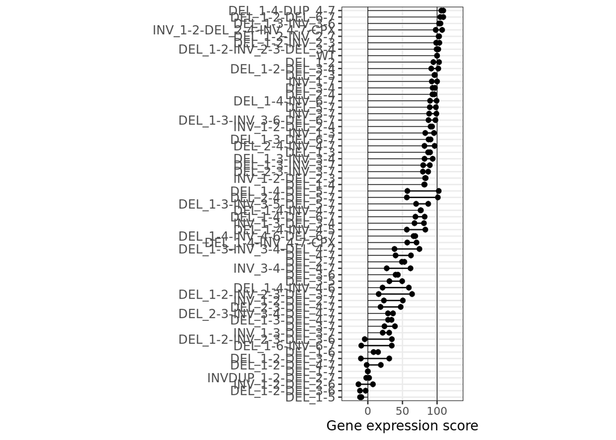

```r
# 61 architectures

# Compute mean and standard deviation over replicates
loxP7.gene.expression.sd.df <- loxP7.gene.expression.df %>% filter(genotype != "DEL_1-6-INVDUP_6-7") %>%
  group_by(genotype) %>%
  summarise(mean = mean(score, na.rm = TRUE),
            diff = max(score, na.rm = TRUE) - mean(score, na.rm = TRUE))

# Plot
loxP7.gene.expression.plot <- loxP7.gene.expression.df %>% filter(genotype != "DEL_1-6-INVDUP_6-7") %>%
  ggplot() +
  geom_bar(aes(x = reorder(genotype, score), y = score),
           position = "dodge", stat = "summary", color = "black",
           size = 0.25, width = 0) +
  geom_errorbar(data = loxP7.gene.expression.sd.df,
                aes(x = genotype, ymin = mean - diff, ymax = mean + diff),
                linewidth = 0.5) +
  geom_point(aes(x = reorder(genotype, -score), y = score), size = 1.5) +
  ylab("Gene expression score") + ylim(-30,130) +
  geom_hline(yintercept = 0, linetype = "solid", linewidth = 0.25) +
  geom_hline(yintercept = 100, linetype = "solid", linewidth = 0.25) +
  theme_bw() +
  theme(aspect.ratio = 3.236,
        panel.grid.minor = element_blank(),
        axis.title.y = element_blank(),
        axis.text.y = element_text(size = 10)) +
  coord_flip()
loxP7.gene.expression.plot
```

```r
pdf("/lustre/scratch126/gengen/projects/escramble/Notebook/Rplots/OTX2/OTX2.loxP7.gene.expression.score.plot.pdf", width=10, height=7, useDingbats=FALSE)
loxP7.gene.expression.plot
dev.off()
```

## 5.4 Effect of inversion

This chunk aims to assess the impact of inversion on gene expression

To do so, we compare the gene expression scores of architectures with inversion with the corresponding architecture with no information

A table is manually generated by associating inverted and non-inverted scores

```r
# R

# Save previous table for modification

write.table(loxP7.gene.expression.df, "./007_OTX2_loxP7_architectures_analysis/loxP7.gene.expression.inversion.tsv", sep = "\t", col.names = T, row.names = F, quote = F)
```

Plot

```r
library(dplyr)
library(tidyr)
library(ggplot2)

# Load modified table

loxP7.gene.expression.inversion.pairs.df <- read.csv("./007_OTX2_loxP7_architectures_analysis/loxP7.gene.expression.inversion.mod.csv")
length(unique(loxP7.gene.expression.inversion.pairs.df$inv_genotype))
```

```
## [1] 33
```

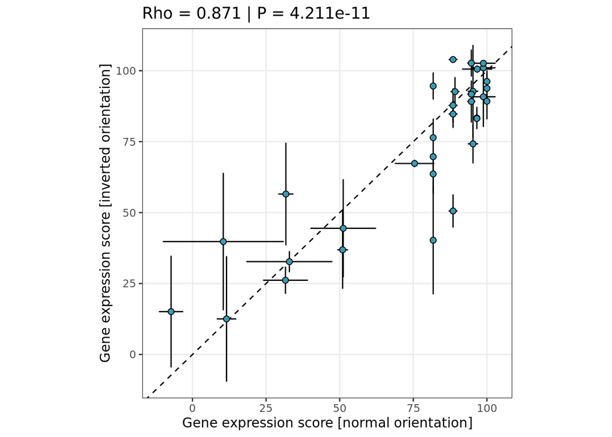

```r
# 33 pairs

# Compute mean and error bars

loxP7.gene.expression.inversion.pairs.df <- loxP7.gene.expression.inversion.pairs.df %>% group_by(inv_genotype) %>%
  summarise(inv.score.mean = mean(inv_score, na.rm = T),
            inv.score.max = max(inv_score, na.rm = T)-inv.score.mean,
            normal.score.mean = mean(normal_score, na.rm = T),
            normal.score.max = max(normal_score, na.rm = T)-normal.score.mean,)

# Compute corelation
Rho <- cor.test(loxP7.gene.expression.inversion.pairs.df$inv.score.mean, loxP7.gene.expression.inversion.pairs.df$normal.score.mean)

# Plot

loxP7.gene.expression.inversion.pairs.plot <- loxP7.gene.expression.inversion.pairs.df %>% ggplot(aes(x = normal.score.mean, y = inv.score.mean)) +
  geom_abline(slope = 1, intercept = 0, linetype = "dashed") +
  geom_errorbar(aes(xmin = normal.score.mean-normal.score.max, xmax = normal.score.mean+normal.score.max)) +
  geom_errorbar(aes(ymin = inv.score.mean-inv.score.max, ymax = inv.score.mean+inv.score.max)) +
  geom_point(size = 2, shape = 21, fill = "#3B9BB3") +
  xlim(-15,110) + ylim(-15,110) + scale_x_continuous(breaks = c(0, 25, 50, 75, 100)) + scale_y_continuous(breaks = c(0, 25, 50, 75, 100)) +
  xlab("Gene expression score [normal orientation]") + ylab("Gene expression score [inverted orientation]") + ggtitle(paste0("Rho = ", round(Rho$estimate,3), " | P = ", sprintf("%.3e", Rho$p.value))) +
  theme_bw() + theme(aspect.ratio=1, panel.grid.minor = element_blank())
loxP7.gene.expression.inversion.pairs.plot
```

```r
pdf("/lustre/scratch126/gengen/projects/escramble/Notebook/Rplots/OTX2/OTX2.loxP7.gene.expression.inversion.pairs.plot.pdf", width=5, height=5, useDingbats=FALSE)
loxP7.gene.expression.inversion.pairs.plot
dev.off()
```

## 5.5 Gene expression score aggregation

The following chunk report the quantification of domain contribution to gene expression by aggregating gene expression scores

```r
# R

loxP7.score.high.conf.aggregate.df <- loxP7.score.high.conf.df %>%
  dplyr::select(genotype = savana_notation_grammar, score.1 = mean_expression_score_1_scaled, score.2 = mean_expression_score_2_scaled, coverage = sum_coverage)  %>%
  mutate(coverage = gsub("^\\(|\\)$", "", coverage)) %>%
  separate(coverage, into = c("R4A", "R4B", "R5A", "R5B", "R5C", "R5D"), sep = ", ", convert = TRUE)

# Aggregate values

loxP7.none.score.df <- loxP7.score.high.conf.aggregate.df %>% filter(R4A == 0 & R4B == 0 & R5A == 0 & R5B == 0 & R5C == 0 & R5D == 0) %>%
  dplyr::select(genotype, score.1, score.2) %>%
  pivot_longer(-genotype, names_to = "region", values_to = "score") %>%
  mutate(domain = "none") %>% dplyr::select(domain, score)
loxP7.R4A.score.df <- loxP7.score.high.conf.aggregate.df %>% filter(R4A == 1) %>%
  dplyr::select(genotype, score.1, score.2) %>%
  pivot_longer(-genotype, names_to = "region", values_to = "score") %>%
  mutate(domain = "R4A") %>% dplyr::select(domain, score)
loxP7.R4B.score.df <- loxP7.score.high.conf.aggregate.df %>% filter(R4B == 1) %>%
  dplyr::select(genotype, score.1, score.2) %>%
  pivot_longer(-genotype, names_to = "region", values_to = "score") %>%
  mutate(domain = "R4B") %>% dplyr::select(domain, score)
loxP7.R5A.score.df <- loxP7.score.high.conf.aggregate.df %>% filter(R5A == 1) %>%
  dplyr::select(genotype, score.1, score.2) %>%
  pivot_longer(-genotype, names_to = "region", values_to = "score") %>%
  mutate(domain = "R5A") %>% dplyr::select(domain, score)
loxP7.R5B.score.df <- loxP7.score.high.conf.aggregate.df %>% filter(R5B == 1) %>%
  dplyr::select(genotype, score.1, score.2) %>%
  pivot_longer(-genotype, names_to = "region", values_to = "score") %>%
  mutate(domain = "R5B") %>% dplyr::select(domain, score)
loxP7.R5C.score.df <- loxP7.score.high.conf.aggregate.df %>% filter(R5C == 1) %>%
  dplyr::select(genotype, score.1, score.2) %>%
  pivot_longer(-genotype, names_to = "region", values_to = "score") %>%
  mutate(domain = "R5C") %>% dplyr::select(domain, score)
loxP7.R5D.score.df <- loxP7.score.high.conf.aggregate.df %>% filter(R5D == 1) %>%
  dplyr::select(genotype, score.1, score.2) %>%
  pivot_longer(-genotype, names_to = "region", values_to = "score") %>%
  mutate(domain = "R5D") %>% dplyr::select(domain, score)
loxP7.WT.score.df <- loxP7.score.high.conf.aggregate.df %>% filter(R4A == 1 & R4B == 1 & R5A == 1 & R5B == 1 & R5C == 1 & R5D == 1) %>%
  dplyr::select(genotype, score.1, score.2) %>%
  pivot_longer(-genotype, names_to = "region", values_to = "score") %>%
  mutate(domain = "all") %>% dplyr::select(domain, score)
loxP7.aggregate.score.df <- rbind(loxP7.none.score.df, loxP7.R4A.score.df, loxP7.R4B.score.df, loxP7.R5A.score.df, loxP7.R5B.score.df, loxP7.R5C.score.df, loxP7.R5D.score.df, loxP7.WT.score.df)
saveRDS(loxP7.aggregate.score.df, "./007_OTX2_loxP7_architectures_analysis/rds/loxP7.aggregate.score.df.rds")
```

Plot

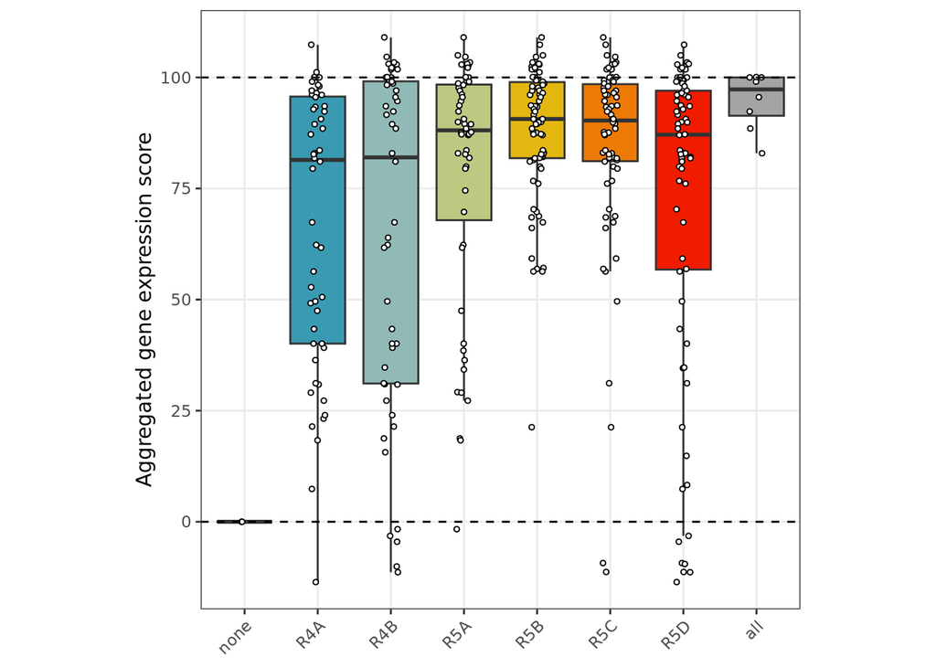

```r
library(dplyr)
library(tidyr)
library(ggplot2)

# Load result
loxP7.aggregate.score.df <- readRDS("/lustre/scratch126/gengen/projects/escramble/Notebook/007_OTX2_loxP7_architectures_analysis/rds/loxP7.aggregate.score.df.rds")

# Plot

loxP7.aggregate.score.plot <- loxP7.aggregate.score.df %>%
  mutate(DOMAIN = fct_relevel(domain, "none", "R4A", "R4B", "R5A", "R5B", "R5C", "R5D", "all")) %>%
  ggplot(aes(x = DOMAIN, y = score*100, fill = DOMAIN)) +
  geom_boxplot(outlier.shape = NA) +
  geom_jitter(width = 0.1, size = 1, shape = 21, fill = "white") +
  ylab("Aggregated gene expression score") + #ylim(-20, 120) +
  scale_y_continuous(breaks = c(0, 25, 50, 75, 100)) +
  geom_hline(yintercept=0, linetype="dashed") +
  geom_hline(yintercept=100, linetype="dashed") +
  scale_fill_manual(values=c("#A4A4A4", wes_palette("Zissou1", 6, type = "continuous"), "#A4A4A4")) +
  theme_bw() + theme(aspect.ratio=1, panel.grid.minor = element_blank(), panel.grid.minor.x = element_blank(), legend.position="none", axis.title.x = element_blank(), axis.text.x = element_text(angle = 45, vjust = 1, hjust=1))
loxP7.aggregate.score.plot
```

```r
pdf("/lustre/scratch126/gengen/projects/escramble/Notebook/Rplots/OTX2/OTX2.loxP7.aggregate.score.plot.pdf", width=5, height=5, useDingbats=FALSE)
loxP7.aggregate.score.plot
dev.off()
```

# 6 Super-enhancer activity

These chunks report the use of of linear models to predict and characterise OTX2 super-enhancer activity according to Dukler et al. Nature Genetics (2017) 49, 2-4

Original scripts and data were recovered from https://github.com/CshlSiepelLab/super-enhancer-code/tree/master

Because inversions do not seem to impact gene expression, we consider only domain coverage for the models

## 6.1 Model selection

This chunck identify the best models and error functions

```r
# R

library(DEoptim)

# Call function to compute the different models
source("/lustre/scratch126/gengen/projects/escramble/Notebook/Scripts/enhancerLib.models.R")

# Load data
loxP7.score.high.conf.df <- read.csv("/lustre/scratch126/gengen/projects/escramble/Data/AN_data/66_high_conf_architectures_scores.tsv", sep = "\t")

# Reformat
loxP7.score.high.conf.melt.df <- loxP7.score.high.conf.df %>%
  select(genotype = savana_notation_grammar, score.1 = mean_expression_score_1_scaled, score.2 = mean_expression_score_2_scaled) %>%
  pivot_longer(cols = c(score.1, score.2), names_to = "rep", values_to = "expression") %>%
  mutate(rep = ifelse(rep == "score.1", 1, 2)) %>%
  left_join((loxP7.score.high.conf.df %>% dplyr::select(genotype = savana_notation_grammar, domain.coverage = sum_coverage)), by = "genotype") %>%
  mutate(domain.coverage = gsub("^\\(|\\)$", "", domain.coverage)) %>%
  separate(domain.coverage, into = c("R4A", "R4B", "R5A", "R5B", "R5C", "R5D"), sep = ", ", convert = TRUE)

# Scale score between 0 and 1
loxP7.score.high.conf.melt.df$expression <- loxP7.score.high.conf.melt.df$expression - min(loxP7.score.high.conf.melt.df$expression)
loxP7.score.high.conf.melt.df$expression <- loxP7.score.high.conf.melt.df$expression/max(loxP7.score.high.conf.melt.df$expression)

# Add pseudocount
loxP7.score.high.conf.melt.df[which(loxP7.score.high.conf.melt.df$expression == 0),]$expression <- 0.01
loxP7.score.high.conf.melt.df$expression <- loxP7.score.high.conf.melt.df$expression*100
saveRDS(loxP7.score.high.conf.melt.df, "./007_OTX2_loxP7_architectures_analysis/rds/loxP7.score.high.conf.melt.df.rds")

# Define response and design matrix
expression <- loxP7.score.high.conf.melt.df$expression
design.df <- as.data.frame(loxP7.score.high.conf.melt.df %>% dplyr::select(R4A, R4B, R5A, R5B, R5C, R5D))

##########################################
# Test models with normal error

# Test linear model with normal error
linear.norm <- deOptim.mod(response = expression,
                           design.mat = design.df,
                           ll.fun = linear.mod, parms = runif(8),
                           lower = c(10^-3, 10^-3, 10^-2, 10^-1, 10, 100 , 200, 200), upper = 200,
                           error.mod = "gaussian", refine = TRUE)
# Generate predictions
pred.linear.norm <- linear.predict(design.mat = design.df, x = linear.norm$par)
saveRDS(pred.linear.norm, "./007_OTX2_loxP7_architectures_analysis/rds/pred.linear.norm.rds")

pvr.plot(pred.linear.norm$expression, expression, loxP7.score.high.conf.melt.df$genotype)
plot.model(model = linear.norm, observed = expression, design.mat = design.df, val.fun = linear.val, error.type = "gaussian")
R.squared.fun(expression, pred.linear.norm$expression) # 0.7722431

# Manually plot model performance

linear.norm.plot.df <- cbind.data.frame(c=as.factor(loxP7.score.high.conf.melt.df$genotype),p=as.numeric(pred.linear.norm$expression),o=as.numeric(expression))
linear.norm.plot.means <- linear.norm.plot.df %>% group_by(c) %>% summarise(p = mean(p), o=mean(o))

linear.norm.plot <- ggplot()+
  geom_point(data=linear.norm.plot.means,aes(x=p,y=o),color="#EE2524",size=3)+
  geom_point(data=linear.norm.plot.df,aes(x=p,y=o))+
  xlim(0,100) + ylim(0,100) +
  geom_abline(slope=1) +
  ylab("Observed [scaled]") +
  xlab("Predicted [scaled]") + ggtitle("Linear/additive - normal error") +
  theme_bw() + theme(aspect.ratio=1, panel.grid.minor = element_blank())
linear.norm.plot

# Test multiplicative model with normal error
multi.norm <- deOptim.mod(response = expression,
                          design.mat = design.df,
                          ll.fun = multiplicative.model, parms = runif(8),
                          lower = c(rep(-50, 7), 10^-4), upper = 200,
                          error.mod="gaussian", refine=TRUE)
# Generate predictions
pred.multi.norm <- multiplicative.predict(design.mat = design.df, x = multi.norm$par)
saveRDS(pred.multi.norm, "./007_OTX2_loxP7_architectures_analysis/rds/pred.multi.norm.rds")

pvr.plot(pred.multi.norm$expression, expression, loxP7.score.high.conf.melt.df$genotype)
plot.model(model = multi.norm, observed = expression, design.mat = design.df, val.fun = multiplicative.val,error.type="gaussian")
R.squared.fun(expression, pred.multi.norm$expression) # 0.7175619

# Manually plot model performance

multi.norm.plot.df <- cbind.data.frame(c=as.factor(loxP7.score.high.conf.melt.df$genotype),p=as.numeric(pred.multi.norm$expression),o=as.numeric(expression))
multi.norm.plot.means <- multi.norm.plot.df %>% group_by(c) %>% summarise(p = mean(p), o=mean(o))

multi.norm.plot <- ggplot()+
  geom_point(data=multi.norm.plot.means,aes(x=p,y=o),color="#EE2524",size=3)+
  geom_point(data=multi.norm.plot.df,aes(x=p,y=o))+
  xlim(0,100) + ylim(0,100) +
  geom_abline(slope=1) +
  ylab("Observed [scaled]") +
  xlab("Predicted [scaled]") + ggtitle("Linear/exponential - normal error") +
  theme_bw() + theme(aspect.ratio=1, panel.grid.minor = element_blank())
multi.norm.plot

## Test logistic model with normal error
log.norm <- deOptim.mod(response = expression,
                        design.mat = design.df,
                        ll.fun=logistic.model, parms = runif(9),
                        lower = c(rep(-50, 8), 10^-3), upper = 200,
                        error.mod="gaussian", refine=TRUE)
# Generate predictions
pred.log.norm <- logistic.predict(design.mat = design.df, x = log.norm$par)
saveRDS(pred.log.norm, "./007_OTX2_loxP7_architectures_analysis/rds/pred.log.norm.rds")

pvr.plot(pred.log.norm$expression, expression, loxP7.score.high.conf.melt.df$genotype)
plot.model(model = log.norm, observed = expression, design.mat = design.df, val.fun = logistic.val, scale= log.norm$par[8], error.type="gaussian")
R.squared.fun(expression, pred.log.norm$expression) # 0.7978861

# Compute enhancers relative contribution

total_var_explained <- var(pred.log.norm$expression)
coeff <- log.norm$par[2:7]
#contributions <- design.df * log.norm$par
contributions <- design.df * coeff[col(design.df)]
var_contributions <- apply(contributions, 2, var)
fraction_contributions <- var_contributions / total_var_explained
fraction_contributions
# rescale contribution to 100
relative_fraction_contributions <- (fraction_contributions + min(fraction_contributions)) / sum(fraction_contributions + min(fraction_contributions))
relative_fraction_contributions
```

```r
# Manually plot model performance

log.norm.plot.df <- cbind.data.frame(c=as.factor(loxP7.score.high.conf.melt.df$genotype),p=as.numeric(pred.log.norm$expression),o=as.numeric(expression))
log.norm.plot.means <- log.norm.plot.df %>% group_by(c) %>% summarise(p = mean(p), o=mean(o))

log.norm.plot <- ggplot()+
  geom_point(data=log.norm.plot.means,aes(x=p,y=o),color="#EE2524",size=3)+
  geom_point(data=log.norm.plot.df,aes(x=p,y=o))+
  xlim(0,100) + ylim(0,100) +
  geom_abline(slope=1) +
  ylab("Observed [scaled]") +
  xlab("Predicted [scaled]") + ggtitle("Linear/logistic - normal error") +
  theme_bw() + theme(aspect.ratio=1, panel.grid.minor = element_blank())
log.norm.plot

# Prepare activity plot

logistic.plot.data.df <- prepare.model.plot.data(model = log.norm, observed = expression, design.mat = design.df, val.fun = logistic.val, scale= log.norm$par[8], error.type="gaussian")
logistic.plot.data.df$real$score <- loxP7.score.high.conf.melt.df$expression
logistic.plot.data.df$out$score <- ((logistic.plot.data.df$out$expression))
logistic.plot.data.df$err$score <- ((logistic.plot.data.df$err$y))
cc <- scales::seq_gradient_pal("#93BBB7", "#93BBB7", "Lab")(seq(0,0.5,length.out=length(unique(logistic.plot.data.df$err$err$Quantile))))

logistic.plot <- ggplot()+
  geom_polygon(data=logistic.plot.data.df$err,aes(x=x,y=score,fill=Quantile),alpha=0.5,fill="#93BBB7")+
  geom_line(data=logistic.plot.data.df$out,aes(activity,score),color="#EE2524",size=1)+
  geom_point(data=logistic.plot.data.df$real,aes(activity,score), shape = 21, fill="white")+
  theme_bw(base_size = 28)+
  xlab("Enhancer activity")+ggtitle("Logistic activity")+
  scale_y_continuous(name="Gene expression score", limits=c(-8, 120),breaks=c(0, 25, 50, 75, 100))+
  geom_hline(yintercept=50, linetype="dashed", color = "black", size=0.5) +
  geom_vline(xintercept=0, linetype="dashed", color = "black", size=0.5) +
  theme_bw() + theme(aspect.ratio=1, panel.grid.minor = element_blank(), legend.position="none")
logistic.plot

# Combine and save plots

pdf("/lustre/scratch126/gengen/projects/escramble/Notebook/Rplots/OTX2/OTX2.loxP7.linear.models.summary.pdf", width=12, height=4, useDingbats=FALSE)
ggarrange(linear.norm.plot, multi.norm.plot, log.norm.plot, logistic.plot, nrow = 1)
dev.off()

##########################################
# Test models with log-normal error

# Test linear model with log-normal error

linear.ln <- deOptim.mod(response = expression,
                         design.mat = design.df,
                         ll.fun = linear.mod, parms = runif(8),
                         lower = c(rep(-200, 7), 10), upper = 200,
                         error.mod = "log-normal", refine = TRUE)
# Generate prediction
pred.linear <- linear.predict(design.mat = design.df, x = linear.ln$par)
saveRDS(pred.linear, "./007_OTX2_loxP7_architectures_analysis/rds/pred.linear.rds")

pvr.plot(pred.linear$expression, expression, loxP7.score.high.conf.melt.df$genotype)
plot.model(model = linear.ln, observed = expression, design.mat =design.df, val.fun = linear.val, error.type = "log-normal")

pvr.dat.linear.ln <- cbind.data.frame(c=as.factor(loxP7.score.high.conf.melt.df$genotype),p=as.numeric(pred.linear$expression),o=as.numeric(expression))
means <- pvr.dat.linear.ln %>% group_by(c) %>% summarise(p = mean(p), o=mean(o))

ggplot()+
  geom_point(data=means,aes(x=p,y=o),color="red",size=3)+
  geom_point(data=pvr.dat.linear.ln,aes(x=p,y=o))+
  xlim(0,100) + ylim(0,100) +
  geom_abline(slope=1)+
  ylab("Observed")+
  xlab("Predicted")+
  theme_bw() + theme(aspect.ratio=1, panel.grid.minor = element_blank())

# Test multiplicative model with log-normal error
multi.ln <- deOptim.mod(response = expression,
                        design.mat = design.df,
                        ll.fun = multiplicative.model, parms = runif(8),
                        lower = c(rep(-200, 7), 10^-2), upper = 200,
                        error.mod = "log-normal", refine = TRUE)
# Generate prediction
pred.multi <- multiplicative.predict(design.mat = design.df, x = multi.ln$par)
saveRDS(pred.multi, "./007_OTX2_loxP7_architectures_analysis/rds/pred.multi.rds")

pvr.plot(pred.multi$expression, expression, loxP7.score.high.conf.melt.df$genotype)
plot.model(model = multi.ln, observed = expression, design.mat = design.df, val.fun = multiplicative.val, error.type = "log-normal")

# Test logistic model with log-normal error
log.ln <- deOptim.mod(response = expression,
                      design.mat = design.df,
                      ll.fun = logistic.model, parms = runif(9),
                      lower = c(rep(-200, 8), 10^-2), upper = 200,
                      error.mod = "log-normal", refine = TRUE)
# Generate prediction
pred.log <- logistic.predict(design.mat = design.df, x = log.ln$par)
saveRDS(pred.log, "./007_OTX2_loxP7_architectures_analysis/rds/pred.log.rds")

pvr.plot(pred.log$expression, expression, loxP7.score.high.conf.melt.df$genotype)
plot.model(model = log.ln, observed = expression, design.mat = design.df, val.fun = logistic.val, scale = log.ln$par[8], error.type = "log-normal")

##########################################
# Compare models

BIC.df <- cbind.data.frame(model = rep(c("Additive", "Exponential", "Logistic"),2),
                           error = c(rep("Normal",3),rep("Log-normal",3)),
                           BIC = c(
                             1,
                             bic(linear.norm,nrow(design.df)) - bic(multi.norm,nrow(design.df)),
                             bic(linear.norm,nrow(design.df)) - bic(log.norm,nrow(design.df)),
                             bic(linear.norm,nrow(design.df)) - bic(linear.ln,nrow(design.df)),
                             bic(linear.norm,nrow(design.df)) - bic(multi.ln,nrow(design.df)),
                             bic(linear.norm,nrow(design.df)) - bic(log.ln,nrow(design.df))
                             ))

BIC.plot <- BIC.df %>%
  mutate(MOD = fct_relevel(model, "Additive", "Exponential", "Logistic")) %>%
  mutate(ERR = fct_relevel(error, "Normal", "Log-normal")) %>%
  ggplot(aes(x=MOD, y=BIC, fill=ERR)) +
  geom_bar(stat = "identity", position="dodge")+
  theme_bw(base_size = 12)+
  xlab("Models")+
  ylab("Relative BIC")+
  scale_fill_manual("Error", values = c("#EE2524", "#93BBB7")) +
  theme_bw() + theme(aspect.ratio=2, panel.grid.minor = element_blank(),axis.title.x=element_blank(),axis.text.x = element_text(angle = 45, vjust = 1, hjust=1))
BIC.plot
```

```r
pdf("/lustre/scratch126/gengen/projects/escramble/Notebook/Rplots/OTX2/OTX2.loxP7.linear.models.BIC.pdf", width=3, height=4, useDingbats=FALSE)
BIC.plot
dev.off()
```

## 6.2 Enhancer domain contribution

This chunck report the quantification of the relative contribution of each enhancer domain

We rerun the logistic-normal model for each replicates individually

```r
# R

# Format data

loxP7.score.high.conf.melt.rep.1.df <- loxP7.score.high.conf.melt.df %>% filter(rep == 1)
expression.rep.1 <- loxP7.score.high.conf.melt.rep.1.df$expression
design.rep.1.df <- as.data.frame(loxP7.score.high.conf.melt.rep.1.df %>% dplyr::select(R4A, R4B, R5A, R5B, R5C, R5D))

loxP7.score.high.conf.melt.rep.2.df <- loxP7.score.high.conf.melt.df %>% filter(rep == 2)
expression.rep.2 <- loxP7.score.high.conf.melt.rep.2.df$expression
design.rep.2.df <- as.data.frame(loxP7.score.high.conf.melt.rep.2.df %>% dplyr::select(R4A, R4B, R5A, R5B, R5C, R5D))

# Select models

log.norm.rep.1 <- deOptim.mod(response = expression.rep.1, design.mat = design.rep.1.df, ll.fun=logistic.model, parms = runif(9), lower = c(rep(-50, 8), 10^-3), upper = 200, error.mod="gaussian", refine=TRUE)
pred.log.norm.rep.1 <- logistic.predict(design.mat = design.rep.1.df, x = log.norm.rep.1$par)
pvr.plot(pred.log.norm.rep.1$expression, expression.rep.1, loxP7.score.high.conf.melt.rep.1.df$genotype)
plot.model(model = log.norm.rep.1, observed = pred.log.norm.rep.1$expression, design.mat = design.rep.1.df, val.fun = logistic.val, scale= log.norm$par[8], error.type="gaussian")

log.norm.rep.2 <- deOptim.mod(response = expression.rep.2, design.mat = design.rep.2.df, ll.fun=logistic.model, parms = runif(9), lower = c(rep(-50, 8), 10^-3), upper = 200, error.mod="gaussian", refine=TRUE)
pred.log.norm.rep.2 <- logistic.predict(design.mat = design.rep.2.df, x = log.norm.rep.2$par)
pvr.plot(pred.log.norm.rep.2$expression, expression.rep.2, loxP7.score.high.conf.melt.rep.2.df$genotype)
plot.model(model = log.norm.rep.2, observed = pred.log.norm.rep.2$expression, design.mat = design.rep.2.df, val.fun = logistic.val, scale= log.norm$par[8], error.type="gaussian")

# Extract enhancer contributions

total.var.explained.rep.1 <- var(pred.log.norm.rep.1$expression)
coeff.rep.1 <- log.norm.rep.1$par[2:7]
contributions.rep.1 <- design.rep.1.df * coeff.rep.1[col(design.rep.1.df)]
var.contributions.rep.1 <- apply(contributions.rep.1, 2, var)
fraction.contributions.rep.1 <- var.contributions.rep.1 / total.var.explained.rep.1
relative.fraction.contributions.rep.1 <- (fraction.contributions.rep.1 + min(fraction.contributions.rep.1)) / sum(fraction.contributions.rep.1 + min(fraction.contributions.rep.1))

total.var.explained.rep.2 <- var(pred.log.norm.rep.2$expression)
coeff.rep.2 <- log.norm.rep.2$par[2:7]
contributions.rep.2 <- design.rep.2.df * coeff.rep.2[col(design.rep.2.df)]
var.contributions.rep.2 <- apply(contributions.rep.2, 2, var)
fraction.contributions.rep.2 <- var.contributions.rep.2 / total.var.explained.rep.2
relative.fraction.contributions.rep.2 <- (fraction.contributions.rep.2 + min(fraction.contributions.rep.2)) / sum(fraction.contributions.rep.2 + min(fraction.contributions.rep.2))

rep <- c("rep.1", "rep.2")
relative.contribution.df <- tibble(domain = names(relative.fraction.contributions.rep.1),
                                                    rep.1 = relative.fraction.contributions.rep.1,
                                                    rep.2 = relative.fraction.contributions.rep.2) %>%
  mutate(mean = rowMeans(.[rep]), sd = rowSds(as.matrix(.[rep])))

relative.contribution.plot <- relative.contribution.df %>% drop_na() %>%
  ggplot() +
  geom_bar(aes(x=domain, y=mean, fill = domain), stat = "summary", col = "black") +
  geom_errorbar(aes(x=domain, ymin=mean-sd, ymax=mean+sd)) +
  ylab("Relative contribution\n[fraction of variance explained]") +
  scale_fill_manual(values=c(wes_palette("Zissou1", 6, type = "continuous"))) +
  geom_hline(yintercept=0, linetype="dashed") +
  theme_bw() + theme(aspect.ratio=1, strip.background = element_blank(), panel.grid.minor = element_blank(), axis.title.x=element_blank(), axis.text.x = element_text(angle = 45, vjust = 1, hjust=1), legend.position="none")
relative.contribution.plot

pdf("/lustre/scratch126/gengen/projects/escramble/Notebook/Rplots/OTX2/OTX2.loxP7.linear.models.feature.contribution.pdf", width=4, height=4, useDingbats=FALSE)
relative.contribution.plot
dev.off()
```

## 6.3 Domain interactions

Previous models supports R5B as the main regulator of OTX2 activity

```r
# R

# Define rescale function
rescale_0_100 <- function(x) {
  (x - min(x)) / (max(x) - min(x)) * 100
}

# R4A

design.R4A.R5B.interaction.df <- design.df %>% mutate(R4A_R5B = R4A * R5B)
dim.model <- ncol(design.R4A.R5B.interaction.df)+3
log.norm.R4A.R5B <- deOptim.mod(response = expression, design.mat = design.R4A.R5B.interaction.df, ll.fun = logistic.model, parms = runif(dim.model), lower = c(rep(-50, dim.model-1), 10^-3), upper = 200, error.mod = "gaussian", refine = TRUE)
pred.log.norm.R4A.R5B <- linear.predict(design.mat = design.R4A.R5B.interaction.df, x = log.norm.R4A.R5B$par) %>% as.data.frame() %>%
  mutate(expression = rescale_0_100(expression))
pvr.plot(pred.log.norm.R4A.R5B$expression, expression, loxP7.score.high.conf.melt.df$genotype)
R4A.bic <- bic(linear.norm,nrow(design.df)) - bic(log.norm.R4A.R5B,nrow(design.R4A.R5B.interaction.df))

# R4B

design.R4B.R5B.interaction.df <- design.df %>% mutate(R4B_R5B = R4B * R5B)
dim.model <- ncol(design.R4B.R5B.interaction.df)+3
log.norm.R4B.R5B <- deOptim.mod(response = expression, design.mat = design.R4B.R5B.interaction.df, ll.fun = logistic.model, parms = runif(dim.model), lower = c(rep(-50, dim.model-1), 10^-3), upper = 200, error.mod = "gaussian", refine = TRUE)
pred.log.norm.R4B.R5B <- linear.predict(design.mat = design.R4B.R5B.interaction.df, x = log.norm.R4B.R5B$par) %>% as.data.frame() %>%
  mutate(expression = rescale_0_100(expression))
pvr.plot(pred.log.norm.R4B.R5B$expression, expression, loxP7.score.high.conf.melt.df$genotype)
R4B.bic <- bic(linear.norm,nrow(design.df)) - bic(log.norm.R4B.R5B,nrow(design.R4B.R5B.interaction.df))
saveRDS(pred.log.norm.R4B.R5B, "./007_OTX2_loxP7_architectures_analysis/rds/pred.log.norm.R4B.R5B.rds")

# R5A

design.R5A.R5B.interaction.df <- design.df %>% mutate(R5A_R5B = R5A * R5B)
dim.model <- ncol(design.R5A.R5B.interaction.df)+3
log.norm.R5A.R5B <- deOptim.mod(response = expression, design.mat = design.R5A.R5B.interaction.df, ll.fun = logistic.model, parms = runif(dim.model), lower = c(rep(-50, dim.model-1), 10^-3), upper = 200, error.mod = "gaussian", refine = TRUE)
pred.log.norm.R5A.R5B <- linear.predict(design.mat = design.R5A.R5B.interaction.df, x = log.norm.R5A.R5B$par) %>% as.data.frame() %>%
  mutate(expression = rescale_0_100(expression))
pvr.plot(pred.log.norm.R5A.R5B$expression, expression, loxP7.score.high.conf.melt.df$genotype)
R5A.bic <- bic(linear.norm,nrow(design.df)) - bic(log.norm.R5A.R5B,nrow(design.R5A.R5B.interaction.df))

# R5C

design.R5C.R5B.interaction.df <- design.df %>% mutate(R5C_R5B = R5C * R5B)
dim.model <- ncol(design.R5C.R5B.interaction.df)+3
log.norm.R5C.R5B <- deOptim.mod(response = expression, design.mat = design.R5C.R5B.interaction.df, ll.fun = logistic.model, parms = runif(dim.model), lower = c(rep(-50, dim.model-1), 10^-3), upper = 200, error.mod = "gaussian", refine = TRUE)
pred.log.norm.R5C.R5B <- linear.predict(design.mat = design.R5C.R5B.interaction.df, x = log.norm.R5C.R5B$par) %>% as.data.frame() %>%
  mutate(expression = rescale_0_100(expression))
pvr.plot(pred.log.norm.R5C.R5B$expression, expression, loxP7.score.high.conf.melt.df$genotype)
R5C.bic <- bic(linear.norm,nrow(design.df)) - bic(log.norm.R5C.R5B,nrow(design.R5C.R5B.interaction.df))

# R5D

design.R5D.R5B.interaction.df <- design.df %>% mutate(R5D_R5B = R5D * R5B)
dim.model <- ncol(design.R5D.R5B.interaction.df)+3
log.norm.R5D.R5B <- deOptim.mod(response = expression, design.mat = design.R5D.R5B.interaction.df, ll.fun = logistic.model, parms = runif(dim.model), lower = c(rep(-50, dim.model-1), 10^-3), upper = 200, error.mod = "gaussian", refine = TRUE)
pred.log.norm.R5D.R5B <- linear.predict(design.mat = design.R5D.R5B.interaction.df, x = log.norm.R5D.R5B$par) %>% as.data.frame() %>%
  mutate(expression = rescale_0_100(expression))
pvr.plot(pred.log.norm.R5D.R5B$expression, expression, loxP7.score.high.conf.melt.df$genotype)
R5D.bic <- bic(linear.norm,nrow(design.df)) - bic(log.norm.R5D.R5B,nrow(design.R5D.R5B.interaction.df))

# R4A_R4B

design.R4A_R4B.R5B.interaction.df <- design.df %>% mutate(R4A_R5B = R4A * R5B, R5D_R5B = R5D * R5B)
dim.model <- ncol(design.R4A_R4B.R5B.interaction.df)+3
log.norm.R4A_R4B.R5B <- deOptim.mod(response = expression, design.mat = design.R4A_R4B.R5B.interaction.df, ll.fun = logistic.model, parms = runif(dim.model), lower = c(rep(-200, dim.model-1), 10^-2), upper = 200, error.mod = "gaussian", refine = TRUE)
pred.log.norm.R4A_R4B.R5B <- linear.predict(design.mat = design.R4A_R4B.R5B.interaction.df, x = log.norm.R4A_R4B.R5B$par) %>% as.data.frame() %>%
  mutate(expression = rescale_0_100(expression))
pvr.plot(pred.log.norm.R4A_R4B.R5B$expression, expression, loxP7.score.high.conf.melt.df$genotype)
R4A_R4B.bic <- bic(linear.norm,nrow(design.df)) - bic(log.norm.R4A_R4B.R5B,nrow(design.R4A_R4B.R5B.interaction.df))

# R4A_R5A

design.R4A_R5A.R5B.interaction.df <- design.df %>% mutate(R4A_R5B = R4A * R5B, R5D_R5B = R5D * R5B)
dim.model <- ncol(design.R4A_R5A.R5B.interaction.df)+3
log.norm.R4A_R5A.R5B <- deOptim.mod(response = expression, design.mat = design.R4A_R5A.R5B.interaction.df, ll.fun = logistic.model, parms = runif(dim.model), lower = c(rep(-200, dim.model-1), 10^-2), upper = 200, error.mod = "gaussian", refine = TRUE)
pred.log.norm.R4A_R5A.R5B <- linear.predict(design.mat = design.R4A_R5A.R5B.interaction.df, x = log.norm.R4A_R5A.R5B$par) %>% as.data.frame() %>%
  mutate(expression = rescale_0_100(expression))
pvr.plot(pred.log.norm.R4A_R5A.R5B$expression, expression, loxP7.score.high.conf.melt.df$genotype)
R4A_R5A.bic <- bic(linear.norm,nrow(design.df)) - bic(log.norm.R4A_R5A.R5B,nrow(design.R4A_R5A.R5B.interaction.df))

# R4A_R5C

design.R4A_R5C.R5B.interaction.df <- design.df %>% mutate(R4A_R5B = R4A * R5B, R5D_R5B = R5D * R5B)
dim.model <- ncol(design.R4A_R5C.R5B.interaction.df)+3
log.norm.R4A_R5C.R5B <- deOptim.mod(response = expression, design.mat = design.R4A_R5C.R5B.interaction.df, ll.fun = logistic.model, parms = runif(dim.model), lower = c(rep(-200, dim.model-1), 10^-2), upper = 200, error.mod = "gaussian", refine = TRUE)
pred.log.norm.R4A_R5C.R5B <- linear.predict(design.mat = design.R4A_R5C.R5B.interaction.df, x = log.norm.R4A_R5C.R5B$par) %>% as.data.frame() %>%
  mutate(expression = rescale_0_100(expression))
pvr.plot(pred.log.norm.R4A_R5C.R5B$expression, expression, loxP7.score.high.conf.melt.df$genotype)
R4A_R5C.bic <- bic(linear.norm,nrow(design.df)) - bic(log.norm.R4A_R5C.R5B,nrow(design.R4A_R5C.R5B.interaction.df))
```

```r
# R4A_R5D

design.R4A_R5D.R5B.interaction.df <- design.df %>% mutate(R4A_R5B = R4A * R5B, R5D_R5B = R5D * R5B)
dim.model <- ncol(design.R4A_R5D.R5B.interaction.df)+3
log.norm.R4A_R5D.R5B <- deOptim.mod(response = expression, design.mat = design.R4A_R5D.R5B.interaction.df, ll.fun = logistic.model, parms = runif(dim.model), lower = c(rep(-200, dim.model-1), 10^-2), upper = 200, error.mod = "gaussian", refine = TRUE)
pred.log.norm.R4A_R5D.R5B <- linear.predict(design.mat = design.R4A_R5D.R5B.interaction.df, x = log.norm.R4A_R5D.R5B$par) %>% as.data.frame() %>%
  mutate(expression = rescale_0_100(expression))
pvr.plot(pred.log.norm.R4A_R5D.R5B$expression, expression, loxP7.score.high.conf.melt.df$genotype)
R4A_R5D.bic <- bic(linear.norm,nrow(design.df)) - bic(log.norm.R4A_R5D.R5B,nrow(design.R4A_R5D.R5B.interaction.df))

# R4B_R5A

design.R4B_R5A.R5B.interaction.df <- design.df %>% mutate(R4B_R5B = R4B * R5B, R5D_R5B = R5D * R5B)
dim.model <- ncol(design.R4B_R5A.R5B.interaction.df)+3
log.norm.R4B_R5A.R5B <- deOptim.mod(response = expression, design.mat = design.R4B_R5A.R5B.interaction.df, ll.fun = logistic.model, parms = runif(dim.model), lower = c(rep(-200, dim.model-1), 10^-2), upper = 200, error.mod = "gaussian", refine = TRUE)
pred.log.norm.R4B_R5A.R5B <- linear.predict(design.mat = design.R4B_R5A.R5B.interaction.df, x = log.norm.R4B_R5A.R5B$par) %>% as.data.frame() %>%
  mutate(expression = rescale_0_100(expression))
pvr.plot(pred.log.norm.R4B_R5A.R5B$expression, expression, loxP7.score.high.conf.melt.df$genotype)
R4B_R5A.bic <- bic(linear.norm,nrow(design.df)) - bic(log.norm.R4B_R5A.R5B,nrow(design.R4B_R5A.R5B.interaction.df))

# R4B_R5C

design.R4B_R5C.R5B.interaction.df <- design.df %>% mutate(R4B_R5B = R4B * R5B, R5D_R5B = R5D * R5B)
dim.model <- ncol(design.R4B_R5C.R5B.interaction.df)+3
log.norm.R4B_R5C.R5B <- deOptim.mod(response = expression, design.mat = design.R4B_R5C.R5B.interaction.df, ll.fun = logistic.model, parms = runif(dim.model), lower = c(rep(-200, dim.model-1), 10^-2), upper = 200, error.mod = "gaussian", refine = TRUE)
pred.log.norm.R4B_R5C.R5B <- linear.predict(design.mat = design.R4B_R5C.R5B.interaction.df, x = log.norm.R4B_R5C.R5B$par) %>% as.data.frame() %>%
  mutate(expression = rescale_0_100(expression))
pvr.plot(pred.log.norm.R4B_R5C.R5B$expression, expression, loxP7.score.high.conf.melt.df$genotype)
R4B_R5C.bic <- bic(linear.norm,nrow(design.df)) - bic(log.norm.R4B_R5C.R5B,nrow(design.R4B_R5C.R5B.interaction.df))

# R4B_R5D

design.R4B_R5D.R5B.interaction.df <- design.df %>% mutate(R4B_R5B = R4B * R5B, R5D_R5B = R5D * R5B)
dim.model <- ncol(design.R4B_R5D.R5B.interaction.df)+3
log.norm.R4B_R5D.R5B <- deOptim.mod(response = expression, design.mat = design.R4B_R5D.R5B.interaction.df, ll.fun = logistic.model, parms = runif(dim.model), lower = c(rep(-200, dim.model-1), 10^-2), upper = 200, error.mod = "gaussian", refine = TRUE)
pred.log.norm.R4B_R5D.R5B <- linear.predict(design.mat = design.R4B_R5D.R5B.interaction.df, x = log.norm.R4B_R5D.R5B$par) %>% as.data.frame() %>%
  mutate(expression = rescale_0_100(expression))
pvr.plot(pred.log.norm.R4B_R5D.R5B$expression, expression, loxP7.score.high.conf.melt.df$genotype)
R4B_R5D.bic <- bic(linear.norm,nrow(design.df)) - bic(log.norm.R4B_R5D.R5B,nrow(design.R4B_R5D.R5B.interaction.df))

# R5A_R5C

design.R5A_R5C.R5B.interaction.df <- design.df %>% mutate(R5A_R5B = R5A * R5B, R5D_R5B = R5D * R5B)
dim.model <- ncol(design.R5A_R5C.R5B.interaction.df)+3
log.norm.R5A_R5C.R5B <- deOptim.mod(response = expression, design.mat = design.R5A_R5C.R5B.interaction.df, ll.fun = logistic.model, parms = runif(dim.model), lower = c(rep(-200, dim.model-1), 10^-2), upper = 200, error.mod = "gaussian", refine = TRUE)
pred.log.norm.R5A_R5C.R5B <- linear.predict(design.mat = design.R5A_R5C.R5B.interaction.df, x = log.norm.R5A_R5C.R5B$par) %>% as.data.frame() %>%
  mutate(expression = rescale_0_100(expression))
pvr.plot(pred.log.norm.R5A_R5C.R5B$expression, expression, loxP7.score.high.conf.melt.df$genotype)
R5A_R5C.bic <- bic(linear.norm,nrow(design.df)) - bic(log.norm.R5A_R5C.R5B,nrow(design.R5A_R5C.R5B.interaction.df))

# R5A_R5D

design.R5A_R5D.R5B.interaction.df <- design.df %>% mutate(R5A_R5B = R5A * R5B, R5D_R5B = R5D * R5B)
dim.model <- ncol(design.R5A_R5D.R5B.interaction.df)+3
log.norm.R5A_R5D.R5B <- deOptim.mod(response = expression, design.mat = design.R5A_R5D.R5B.interaction.df, ll.fun = logistic.model, parms = runif(dim.model), lower = c(rep(-200, dim.model-1), 10^-2), upper = 200, error.mod = "gaussian", refine = TRUE)
pred.log.norm.R5A_R5D.R5B <- linear.predict(design.mat = design.R5A_R5D.R5B.interaction.df, x = log.norm.R5A_R5D.R5B$par) %>% as.data.frame() %>%
  mutate(expression = rescale_0_100(expression))
pvr.plot(pred.log.norm.R5A_R5D.R5B$expression, expression, loxP7.score.high.conf.melt.df$genotype)
R5A_R5D.bic <- bic(linear.norm,nrow(design.df)) - bic(log.norm.R5A_R5D.R5B,nrow(design.R5A_R5D.R5B.interaction.df))

# R5C_R5D

design.R5C_R5D.R5B.interaction.df <- design.df %>% mutate(R5A_R5B = R5A * R5B, R5D_R5B = R5D * R5B)
dim.model <- ncol(design.R5C_R5D.R5B.interaction.df)+3
log.norm.R5C_R5D.R5B <- deOptim.mod(response = expression, design.mat = design.R5C_R5D.R5B.interaction.df, ll.fun = logistic.model, parms = runif(dim.model), lower = c(rep(-200, dim.model-1), 10^-2), upper = 200, error.mod = "gaussian", refine = TRUE)
pred.log.norm.R5C_R5D.R5B <- linear.predict(design.mat = design.R5C_R5D.R5B.interaction.df, x = log.norm.R5C_R5D.R5B$par) %>% as.data.frame() %>%
  mutate(expression = rescale_0_100(expression))
pvr.plot(pred.log.norm.R5C_R5D.R5B$expression, expression, loxP7.score.high.conf.melt.df$genotype)
R5C_R5D.bic <- bic(linear.norm,nrow(design.df)) - bic(log.norm.R5C_R5D.R5B,nrow(design.R5C_R5D.R5B.interaction.df))

# R4A_R4B_R5A

design.R4A_R4B_R5A.R5B.interaction.df <- design.df %>% mutate(R4A_R5B = R4A * R5B, R4B_R5B = R4B * R5B, R5A_R5B = R5A * R5B)
dim.model <- ncol(design.R4A_R4B_R5A.R5B.interaction.df)+3
log.norm.R4A_R4B_R5A.R5B <- deOptim.mod(response = expression, design.mat = design.R4A_R4B_R5A.R5B.interaction.df, ll.fun = logistic.model, parms = runif(dim.model), lower = c(rep(-200, dim.model-1), 10^-2), upper = 200, error.mod = "gaussian", refine = TRUE)
pred.log.norm.R4A_R4B_R5A.R5B <- linear.predict(design.mat = design.R4A_R4B_R5A.R5B.interaction.df, x = log.norm.R4A_R4B_R5A.R5B$par) %>% as.data.frame() %>%
  mutate(expression = rescale_0_100(expression))
pvr.plot(pred.log.norm.R4A_R4B_R5A.R5B$expression, expression, loxP7.score.high.conf.melt.df$genotype)
R4A_R4B_R5A.bic <- bic(linear.norm,nrow(design.df)) - bic(log.norm.R4A_R4B_R5A.R5B,nrow(design.R4A_R4B_R5A.R5B.interaction.df))
```

```r
# R4A_R4B_R5C

design.R4A_R4B_R5C.R5B.interaction.df <- design.df %>% mutate(R4A_R5B = R4A * R5B, R4B_R5B = R4B * R5B, R5C_R5B = R5C * R5B)
dim.model <- ncol(design.R4A_R4B_R5C.R5B.interaction.df)+3
log.norm.R4A_R4B_R5C.R5B <- deOptim.mod(response = expression, design.mat = design.R4A_R4B_R5C.R5B.interaction.df, ll.fun = logistic.model, parms = runif(dim.model), lower = c(rep(-200, dim.model-1), 10^-2), upper = 200, error.mod = "gaussian", refine = TRUE)
pred.log.norm.R4A_R4B_R5C.R5B <- linear.predict(design.mat = design.R4A_R4B_R5C.R5B.interaction.df, x = log.norm.R4A_R4B_R5C.R5B$par) %>% as.data.frame() %>%
  mutate(expression = rescale_0_100(expression))
pvr.plot(pred.log.norm.R4A_R4B_R5C.R5B$expression, expression, loxP7.score.high.conf.melt.df$genotype)
R4A_R4B_R5C.bic <- bic(linear.norm,nrow(design.df)) - bic(log.norm.R4A_R4B_R5C.R5B,nrow(design.R4A_R4B_R5C.R5B.interaction.df))

# R4A_R4B_R5D

design.R4A_R4B_R5D.R5B.interaction.df <- design.df %>% mutate(R4A_R5B = R4A * R5B, R4B_R5B = R4B * R5B, R5D_R5B = R5D * R5B)
dim.model <- ncol(design.R4A_R4B_R5D.R5B.interaction.df)+3
log.norm.R4A_R4B_R5D.R5B <- deOptim.mod(response = expression, design.mat = design.R4A_R4B_R5D.R5B.interaction.df, ll.fun = logistic.model, parms = runif(dim.model), lower = c(rep(-200, dim.model-1), 10^-2), upper = 200, error.mod = "gaussian", refine = TRUE)
pred.log.norm.R4A_R4B_R5D.R5B <- linear.predict(design.mat = design.R4A_R4B_R5D.R5B.interaction.df, x = log.norm.R4A_R4B_R5D.R5B$par) %>% as.data.frame() %>%
  mutate(expression = rescale_0_100(expression))
pvr.plot(pred.log.norm.R4A_R4B_R5D.R5B$expression, expression, loxP7.score.high.conf.melt.df$genotype)
R4A_R4B_R5D.bic <- bic(linear.norm,nrow(design.df)) - bic(log.norm.R4A_R4B_R5D.R5B,nrow(design.R4A_R4B_R5D.R5B.interaction.df))

# R4B_R5A_R5C

design.R4B_R5A_R5C.R5B.interaction.df <- design.df %>% mutate(R4B_R5B = R4B * R5B, R5A_R5B = R5A * R5B, R5C_R5B = R5C * R5B)
dim.model <- ncol(design.R4B_R5A_R5C.R5B.interaction.df)+3
log.norm.R4B_R5A_R5C.R5B <- deOptim.mod(response = expression, design.mat = design.R4B_R5A_R5C.R5B.interaction.df, ll.fun = logistic.model, parms = runif(dim.model), lower = c(rep(-200, dim.model-1), 10^-2), upper = 200, error.mod = "gaussian", refine = TRUE)
pred.log.norm.R4B_R5A_R5C.R5B <- linear.predict(design.mat = design.R4B_R5A_R5C.R5B.interaction.df, x = log.norm.R4B_R5A_R5C.R5B$par) %>% as.data.frame() %>%
  mutate(expression = rescale_0_100(expression))
pvr.plot(pred.log.norm.R4B_R5A_R5C.R5B$expression, expression, loxP7.score.high.conf.melt.df$genotype)
R4B_R5A_R5C.bic <- bic(linear.norm,nrow(design.df)) - bic(log.norm.R4B_R5A_R5C.R5B,nrow(design.R4B_R5A_R5C.R5B.interaction.df))

# R4B_R5A_R5D

design.R4B_R5A_R5D.R5B.interaction.df <- design.df %>% mutate(R4B_R5B = R4B * R5B, R5A_R5B = R5A * R5B, R5D_R5B = R5D * R5B)
dim.model <- ncol(design.R4B_R5A_R5D.R5B.interaction.df)+3
log.norm.R4B_R5A_R5D.R5B <- deOptim.mod(response = expression, design.mat = design.R4B_R5A_R5D.R5B.interaction.df, ll.fun = logistic.model, parms = runif(dim.model), lower = c(rep(-200, dim.model-1), 10^-2), upper = 200, error.mod = "gaussian", refine = TRUE)
pred.log.norm.R4B_R5A_R5D.R5B <- linear.predict(design.mat = design.R4B_R5A_R5D.R5B.interaction.df, x = log.norm.R4B_R5A_R5D.R5B$par) %>% as.data.frame() %>%
  mutate(expression = rescale_0_100(expression))
pvr.plot(pred.log.norm.R4B_R5A_R5D.R5B$expression, expression, loxP7.score.high.conf.melt.df$genotype)
R4B_R5A_R5D.bic <- bic(linear.norm,nrow(design.df)) - bic(log.norm.R4B_R5A_R5D.R5B,nrow(design.R4B_R5A_R5D.R5B.interaction.df))

# R5A_R5C_R5D

design.R5A_R5C_R5D.R5B.interaction.df <- design.df %>% mutate(R4B_R5B = R4B * R5B, R5A_R5B = R5A * R5B, R5D_R5B = R5D * R5B)
dim.model <- ncol(design.R5A_R5C_R5D.R5B.interaction.df)+3
log.norm.R5A_R5C_R5D.R5B <- deOptim.mod(response = expression, design.mat = design.R5A_R5C_R5D.R5B.interaction.df, ll.fun = logistic.model, parms = runif(dim.model), lower = c(rep(-200, dim.model-1), 10^-2), upper = 200, error.mod = "gaussian", refine = TRUE)
pred.log.norm.R5A_R5C_R5D.R5B <- linear.predict(design.mat = design.R5A_R5C_R5D.R5B.interaction.df, x = log.norm.R5A_R5C_R5D.R5B$par) %>% as.data.frame() %>%
  mutate(expression = rescale_0_100(expression))
pvr.plot(pred.log.norm.R5A_R5C_R5D.R5B$expression, expression, loxP7.score.high.conf.melt.df$genotype)
R5A_R5C_R5D.bic <- bic(linear.norm,nrow(design.df)) - bic(log.norm.R5A_R5C_R5D.R5B,nrow(design.R5A_R5C_R5D.R5B.interaction.df))

# R4A_R4B_R5A_R5C

design.R4A_R4B_R5A_R5C.R5B.interaction.df <- design.df %>% mutate(R4A_R5B = R4A * R5B, R4B_R5B = R4B * R5B, R5A_R5B = R5A * R5B, R5C_R5B = R5C * R5B)
dim.model <- ncol(design.R4A_R4B_R5A_R5C.R5B.interaction.df)+3
log.norm.R4A_R4B_R5A_R5C.R5B <- deOptim.mod(response = expression, design.mat = design.R4A_R4B_R5A_R5C.R5B.interaction.df, ll.fun = logistic.model, parms = runif(dim.model), lower = c(rep(-200, dim.model-1), 10^-2), upper = 200, error.mod = "gaussian", refine = TRUE)
pred.log.norm.R4A_R4B_R5A_R5C.R5B <- linear.predict(design.mat = design.R4A_R4B_R5A_R5C.R5B.interaction.df, x = log.norm.R4A_R4B_R5A_R5C.R5B$par) %>% as.data.frame() %>%
  mutate(expression = rescale_0_100(expression))
pvr.plot(pred.log.norm.R4A_R4B_R5A_R5C.R5B$expression, expression, loxP7.score.high.conf.melt.df$genotype)
R4A_R4B_R5A_R5C.bic <- bic(linear.norm,nrow(design.df)) - bic(log.norm.R4A_R4B_R5A_R5C.R5B,nrow(design.R4A_R4B_R5A_R5C.R5B.interaction.df))

# R4A_R4B_R5A_R5D

design.R4A_R4B_R5A_R5D.R5B.interaction.df <- design.df %>% mutate(R4A_R5B = R4A * R5B, R4B_R5B = R4B * R5B, R5A_R5B = R5A * R5B, R5D_R5B = R5D * R5B)
dim.model <- ncol(design.R4A_R4B_R5A_R5D.R5B.interaction.df)+3
log.norm.R4A_R4B_R5A_R5D.R5B <- deOptim.mod(response = expression, design.mat = design.R4A_R4B_R5A_R5D.R5B.interaction.df, ll.fun = logistic.model, parms = runif(dim.model), lower = c(rep(-200, dim.model-1), 10^-2), upper = 200, error.mod = "gaussian", refine = TRUE)
pred.log.norm.R4A_R4B_R5A_R5D.R5B <- linear.predict(design.mat = design.R4A_R4B_R5A_R5D.R5B.interaction.df, x = log.norm.R4A_R4B_R5A_R5D.R5B$par) %>% as.data.frame() %>%
  mutate(expression = rescale_0_100(expression))
pvr.plot(pred.log.norm.R4A_R4B_R5A_R5D.R5B$expression, expression, loxP7.score.high.conf.melt.df$genotype)
R4A_R4B_R5A_R5D.bic <- bic(linear.norm,nrow(design.df)) - bic(log.norm.R4A_R4B_R5A_R5D.R5B,nrow(design.R4A_R4B_R5A_R5D.R5B.interaction.df))
```

```r
# all

design.all.R5B.interaction.df <- design.df %>% mutate(R4A_R5B = R4A * R5B, R4B_R5B = R4B * R5B, R5A_R5B = R5A * R5B, R5C_R5B = R5C * R5B, R5D_R5B = R5D * R5B)
dim.model <- ncol(design.all.R5B.interaction.df)+3
log.norm.all.R5B <- deOptim.mod(response = expression, design.mat = design.all.R5B.interaction.df, ll.fun = logistic.model, parms = runif(dim.model), lower = c(rep(-200, dim.model-1), 10^-2), upper = 200, error.mod = "gaussian", refine = TRUE)
pred.log.norm.all.R5B <- linear.predict(design.mat = design.all.R5B.interaction.df, x = log.norm.all.R5B$par) %>% as.data.frame() %>%
  mutate(expression = rescale_0_100(expression))
pvr.plot(pred.log.norm.all.R5B$expression, expression, loxP7.score.high.conf.melt.df$genotype)
all.bic <- bic(linear.norm,nrow(design.df)) - bic(log.norm.all.R5B,nrow(design.all.R5B.interaction.df))

# Combine all information and draw conclusion

interaction.BIC.df <- cbind.data.frame(domain = c("none", "R4A", "R4B", "R5A", "R5C", "R5D", "R4A:R4B", "R4A:R5A", "R4A:R5C", "R4A:R5D", "R4B:R5A", "R4B:R5C", "R4B:R5D", "R5A:R5C", "R5A:R5D", "R5C:R5D", "R4A:R4B:R5A", "R4A:R4B:R5C", "R4A:R4B:R5D", "R4B:R5A:R5C", "R4B:R5A:R5D", "R5A:R5C:R5D", "R4A:R4B:R5A:R5C", "R4A:R4B:R5A:R5D", "R4A:R4B:R4B:R5A:R5D"),
                                       BIC = c(0.2, R4A.bic, R4B.bic, R5A.bic, R5C.bic, R5D.bic, R4A_R4B.bic, R4A_R5A.bic, R4A_R5C.bic, R4A_R5D.bic, R4B_R5A.bic, R4B_R5C.bic, R4B_R5D.bic, R5A_R5C.bic, R5A_R5D.bic, R5C_R5D.bic, R4A_R4B_R5A.bic, R4A_R4B_R5C.bic, R4A_R4B_R5D.bic, R4B_R5A_R5C.bic, R4B_R5A_R5D.bic, R5A_R5C_R5D.bic, R4A_R4B_R5A_R5C.bic, R4A_R4B_R5A_R5D.bic, all.bic))
saveRDS(interaction.BIC.df, "./Notebook/007_OTX2_loxP7_architectures_analysis/rds/interaction.BIC.df.rds")

BIC.interaction.plot <- interaction.BIC.df %>%
  mutate(DOM = fct_relevel(domain, "none", "R4A", "R4B", "R5A", "R5C", "R5D", "R4A:R4B", "R4A:R5A", "R4A:R5C", "R4A:R5D", "R4B:R5A", "R4B:R5C", "R4B:R5D", "R5A:R5C", "R5A:R5D", "R5C:R5D", "R4A:R4B:R5A", "R4A:R4B:R5C", "R4A:R4B:R5D", "R4B:R5A:R5C", "R4B:R5A:R5D", "R5A:R5C:R5D", "R4A:R4B:R5A:R5C", "R4A:R4B:R5A:R5D", "R4A:R4B:R4B:R5A:R5D")) %>%
  ggplot(aes(x=DOM, y=BIC)) +
  geom_bar(stat = "identity", fill = "#EE2524")+
  theme_bw(base_size = 12)+
  xlab("Models")+
  ylab("Relative BIC")+
  theme_bw() + theme(aspect.ratio=0.5, panel.grid.minor = element_blank(),axis.title.x=element_blank(),axis.text.x = element_text(angle = 45, vjust = 1, hjust=1))
BIC.interaction.plot

# Prepare plot reporting the best model

best.model.plot.df <- cbind.data.frame(c=as.factor(loxP7.score.high.conf.melt.df$genotype),p=as.numeric(pred.log.norm.R4B.R5B$expression),o=as.numeric(expression))
best.model.plot.means <- best.model.plot.df %>% group_by(c) %>% summarise(p = mean(p), o=mean(o))

best.model.plot <- ggplot()+
  geom_point(data=best.model.plot.means,aes(x=p,y=o),color="#EE2524",size=3)+
  geom_point(data=best.model.plot.df,aes(x=p,y=o))+
  xlim(0,100) + ylim(0,100) +
  geom_abline(slope=1) +
  ylab("Observed [scaled]") +
  xlab("Predicted [scaled]") + ggtitle("Logistic/normal - R4B:R5B interaction") +
  theme_bw() + theme(aspect.ratio=1, panel.grid.minor = element_blank())
best.model.plot

# Save plots

pdf("/lustre/scratch126/gengen/projects/escramble/Notebook/Rplots/OTX2/OTX2.loxP7.linear.models.interaction.pdf", width=12, height=4, useDingbats=FALSE)
ggarrange(BIC.interaction.plot, best.model.plot, nrow = 1)
dev.off()
```

# 7 eScramble characterisation

These chunks reports the features of the scramble workflow

## 7.1 Resampling

Test the number of detected variant from resampling sequencing read This is a simulation as we just consider the theoritical number of reads from in silico resampling

```r
# R

# Load results
architecture.134.score.df <- read.csv("/lustre/scratch126/gengen/projects/escramble/Data/AN_data/134_architectures_scores.csv")
# 134 architectures

# Reformat
architecture.134.read.count.df <- architecture.134.score.df %>%
    mutate(read.count.1 = read_count_very_dim_1+read_count_dim_1+read_count_bright_1+read_count_very_bright_1,
           read.count.2 = read_count_very_dim_2+read_count_dim_2+read_count_bright_2+read_count_very_bright_2,
           read.count = read.count.1 + read.count.2) %>%
  dplyr::select(genotype = savana_notation_grammar, read.count.1, read.count.2, read.count)

# Add information about all reads that do not show evidences for SV
# Total number of reads, Rep 1: 10,943,109 reads, Rep 2: 10,181,336 reads, Total: 21,124,445
# 5,665,154 reads are associated with SVs --> 15,459,291 junk reads

architecture.134.read.count.df <- rbind(architecture.134.read.count.df, cbind.data.frame(genotype = "junk", read.count = 15459291))

# Create vector for resampling

SV.sampling <- rep(architecture.134.read.count.df$genotype, architecture.134.read.count.df$read.count) # 21,124,445 reads

# Sample

# Define sample sizes

n <- c(1, 3, 11, 37, 122, 405, 1346, 4472, 14860, 49376, 164067, 545159, 1811447, 6019049, 20000000)
n <- rep(n, 100)

resampling.df <- tibble()
for (i in n) {
  print(i)
  read.count.i <- i
  samp.i <- sample(SV.sampling, read.count.i)
  table.i <- as.data.frame(table(samp.i)) %>% filter(samp.i != "junk")
    SV.count.1.i <- nrow(table.i %>% filter(Freq >= 1))
    SV.count.10.i <- nrow(table.i %>% filter(Freq >= 10))
    SV.count.100.i <- nrow(table.i %>% filter(Freq >= 100))
    SV.count.1000.i <- nrow(table.i %>% filter(Freq >= 1000))
    SV.count.10000.i <- nrow(table.i %>% filter(Freq >= 10000))
  summary.df.i <- cbind.data.frame(read.count = read.count.i, SV.occurence = c(1, 10, 100, 1000, 10000), SV.count = c(SV.count.1.i, SV.count.10.i, SV.count.100.i, SV.count.1000.i, SV.count.10000.i))
  resampling.df <- rbind(resampling.df, summary.df.i)
}
saveRDS(resampling.df, "/lustre/scratch126/gengen/projects/escramble/Notebook/007_OTX2_loxP7_architectures_analysis/rds/resampling.df.rds")
```

Plot

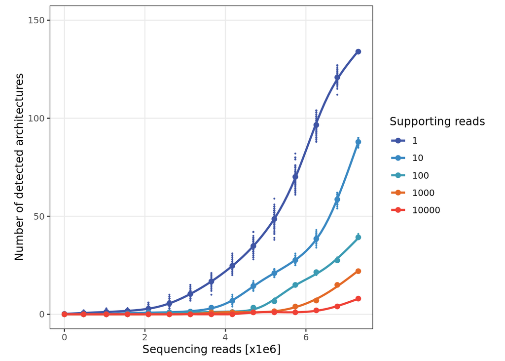

```r
library(dplyr)
library(ggplot2)
library(ggpubr)

resampling.df <- readRDS("/lustre/scratch126/gengen/projects/escramble/Notebook/007_OTX2_loxP7_architectures_analysis/rds/resampling.df.rds")

resampling.plot <- resampling.df %>% mutate(log10.read.count = log10(read.count)) %>%
  ggplot(aes(x = log10.read.count, y = SV.count, colour = as.character(SV.occurence))) +
  geom_smooth(aes(group = as.character(SV.occurence)), span = 3, se = F) +
  geom_point(aes(x = log10.read.count, y = SV.count), size = 0.25) +
  geom_point(stat='summary', fun.y=sum, group=1, size = 2) +
  ylab("Number of detected architectures") + xlab("Sequencing reads [x1e6]") + ylim(0,150) +
  scale_color_manual("Supporting reads", values = c("#3E54A4", "#3988C2", "#3B9BB3", "#E36826", "#EF4136")) +
  theme_bw() + theme(aspect.ratio=1, strip.background = element_blank(), panel.grid.minor = element_blank())
resampling.plot
```

## 7.2 Biases

Characterise biases in detecting and quantifying genotypes

A table is manually generated to compute SV length

```r
# R

write.table(architecture.134.read.count.df, "./007_OTX2_loxP7_architectures_analysis/loxP7.SV.length.tsv", sep = "\t", col.names = T, row.names = F, quote = F)
```

Open modified files and analyse

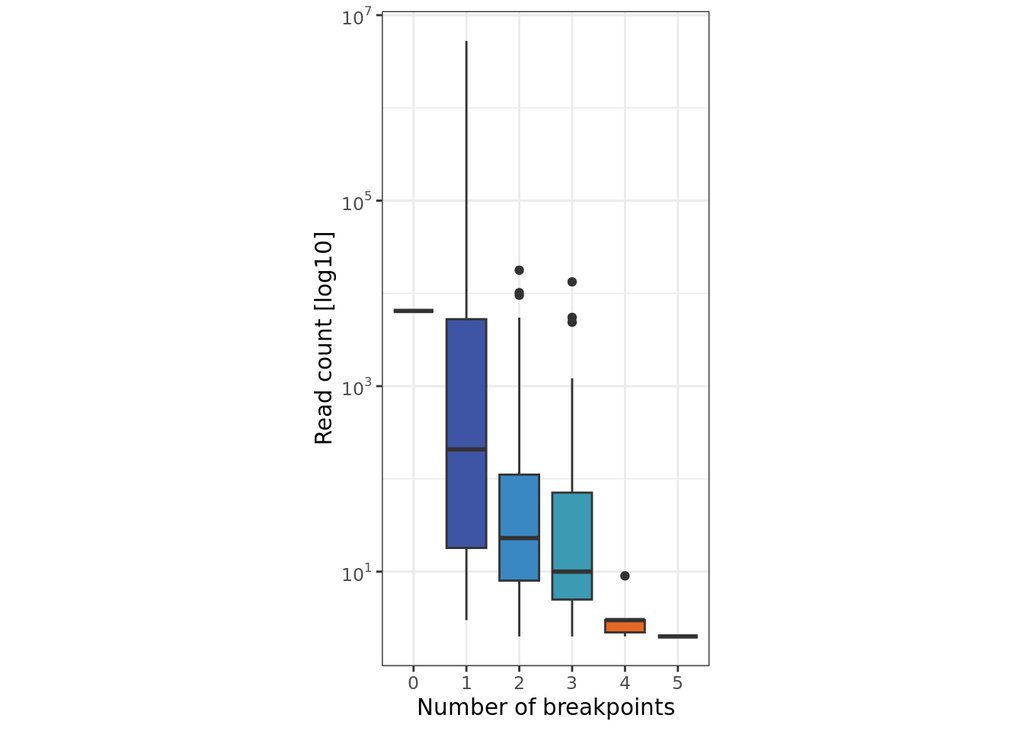

```r
library(dplyr)
library(ggplot2)
library(ggpubr)
library(scales)

# Load data
architecture.134.read.count.df <- read.csv("./007_OTX2_loxP7_architectures_analysis/loxP7.SV.length.mod.csv")

# Define loxPsym sites coordinates
loxPsym.coordinates <- c(56884634, 56893129, 56898376, 56901292, 56903183, 56904792, 56907608)
loxPsym.sorted.coordinates <- loxPsym.coordinates[order(loxPsym.coordinates)]
loxPsym.coordinates.df <- tibble(sites = c(1:7), pos = loxPsym.sorted.coordinates)

# Compute distances from all loxPsym sites
loxPsym.sites.dist.df <- expand_grid(sites = c(1:7), sites.2 = c(1:7)) %>% left_join(loxPsym.coordinates.df %>%
                         dplyr::select(sites, pos.1 = pos)) %>% left_join(loxPsym.coordinates.df %>%
                         dplyr::select(sites.2 = sites, pos.2 = pos)) %>% mutate(dist = pos.1 - pos.2) %>% filter(dist > 0) %>% arrange(-dist)
loxPsym.sites.dist.df <- rbind(loxPsym.sites.dist.df, c(sites = 0, sites.2 = 0, pos.1 = 0, pos.2 = 0, dist = 0))

# Compute read length
architecture.134.read.length.df <- architecture.134.read.count.df %>%
  left_join((loxPsym.sites.dist.df %>% dplyr::select(loxpsym.2 = sites, loxpsym.1 = sites.2, dist.1 = dist))) %>%
  left_join((loxPsym.sites.dist.df %>% dplyr::select(loxpsym.4 = sites, loxpsym.3 = sites.2, dist.2 = dist))) %>%
  mutate(read.length = 23370-(dist.1+dist.2))

# Plot corelation between number of breakpoint and read count

read.lenght.vs.BP.plot <- architecture.134.read.length.df %>% ggplot(aes(x=as.character(BP.count), y=read.count, fill=as.character(BP.count))) +
  geom_boxplot() +
  scale_fill_manual("Number of\nbreakpoints", values = c("white", "#3E54A4", "#3988C2", "#3B9BB3", "#E36826", "#EF4136")) +
  scale_y_continuous(trans='log10', labels = trans_format("log10", math_format(10^.x))) +
  xlab("Number of breakpoints") + ylab("Read count [log10]") +
  theme_bw() + theme(aspect.ratio=2, panel.grid.minorr = element_blank(),legend.position = "none")
read.lenght.vs.BP.plot
```

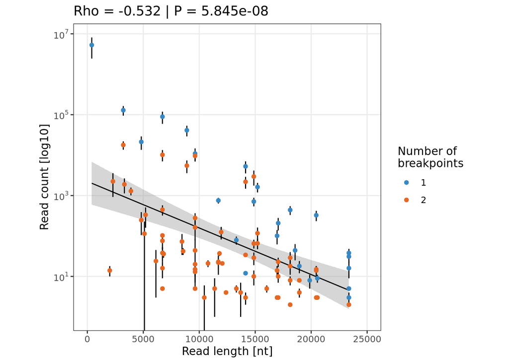

```r
# Plot corelation between read length and read count

architecture.134.BP.2.read.length.df <- architecture.134.read.length.df %>% filter(BP.count >= 1 & BP.count <= 2)
Rho.length <- cor.test(architecture.134.BP.2.read.length.df$read.length, log10(architecture.134.BP.2.read.length.df$read.count))

read.lenght.vs.count.plot <- architecture.134.BP.2.read.length.df %>% ggplot(aes(x=read.length, y=read.count)) +
  geom_smooth(method = "lm", se = TRUE, size = 0.5, col = "black") +
  geom_errorbar(aes(ymin = read.count-read.count.1, ymax = read.count+read.count.1), width = 0.2) +
  geom_point(aes(col=as.character(BP.count))) + xlim(0, 25000) + scale_y_continuous(trans='log10', labels = trans_format("log10", math_format(10^.x))) +
  scale_color_manual("Number of\nbreakpoints", values = c("#3988C2", "#E36826")) +
  xlab("Read length [nt]") + ylab("Read count [log10]") +
  ggtitle(paste0("Rho = ", round(Rho.length$estimate,3), " | P = ", sprintf("%.3e", Rho.length$p.value))) +
  theme_bw() + theme(aspect.ratio=1, panel.grid.minor = element_blank())
read.lenght.vs.count.plot
```

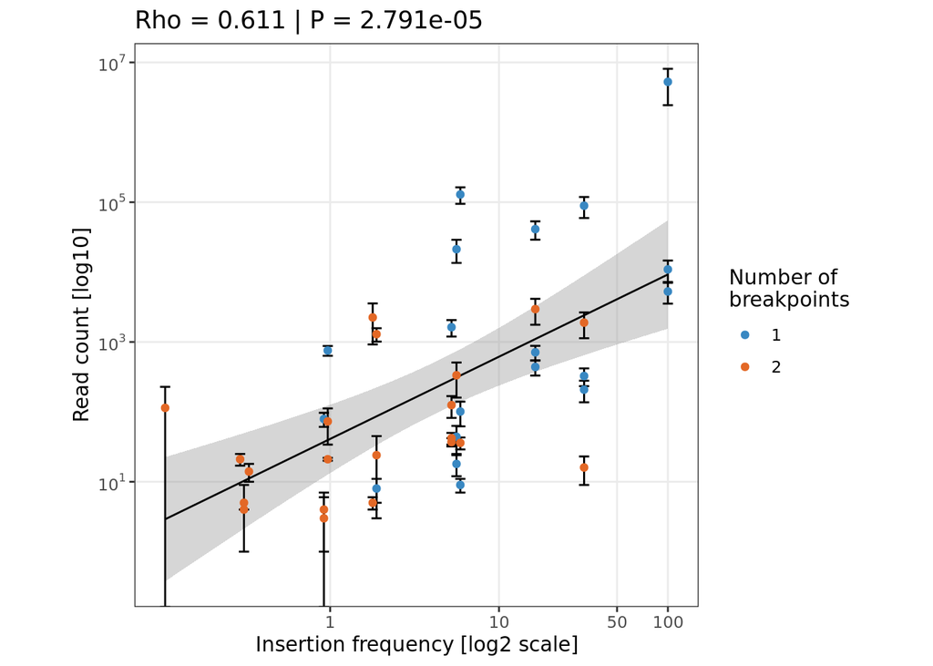

```r
# Plot corelation between LoxPsym insertion frequency and read count

# Create df reporting experimental insertion frequency and prepare summarising plot

insert.freq.df <- tibble(sites = c(0:7), site.freq = c(1, 1, 0.164, 1, 0.319, 0.056, 0.059, 1))

architecture.134.insert.freq.df <- architecture.134.read.count.df %>%
  left_join((insert.freq.df %>% dplyr::select(loxpsym.1 = sites, site.1.freq = site.freq))) %>%
  left_join((insert.freq.df %>% dplyr::select(loxpsym.2 = sites, site.2.freq = site.freq))) %>%
  left_join((insert.freq.df %>% dplyr::select(loxpsym.3 = sites, site.3.freq = site.freq))) %>%
  left_join((insert.freq.df %>% dplyr::select(loxpsym.4 = sites, site.4.freq = site.freq))) %>%
  mutate(loxPsym.freq = (site.1.freq*site.2.freq*site.3.freq*site.4.freq)*100)

# Select only deletion architectures

deletion.insert.freq.df <- architecture.134.insert.freq.df %>%
  filter(!grepl("INV", genotype)) %>%
  filter(!grepl("CPX", genotype)) %>%
  filter(BP.count >= 1)

Rho.freq <- cor.test(log2(deletion.insert.freq.df$loxPsym.freq), log10(deletion.insert.freq.df$read.count))
deletion.insert.freq.plot <- deletion.insert.freq.df %>%
  ggplot(aes(x=loxPsym.freq, y=read.count)) +
  geom_smooth(method = "lm", se = TRUE, size = 0.5, col = "black") +
  geom_errorbar(aes(ymin = read.count-read.count.1, ymax = read.count+read.count.1), width = 0.2) +
  geom_point(aes(col=as.character(BP.count)), size = 1.5) +
  scale_y_continuous(trans='log10', labels = trans_format("log10", math_format(10^.x))) +
  scale_x_continuous(trans = log2_trans(), breaks = c(0, 1, 10, 50, 100)) +
  xlab("Insertion frequency [log2 scale]") + ylab("Read count [log10]") +
  ggtitle(paste0("Rho = ", round(Rho.freq$estimate,3), " | P = ", sprintf("%.3e", Rho.freq$p.value))) +
  scale_color_manual("Number of\nbreakpoints", values = c("#3988C2", "#E36826")) +
  theme_bw() + theme(aspect.ratio=1, panel.grid.minor = element_blank())
deletion.insert.freq.plot
```

```r
pdf("/lustre/scratch126/gengen/projects/escramble/Notebook/Rplots/OTX2/OTX2.loxP7.scrambling.characterisation.pdf", width=18, height=4, useDingbats=FALSE)
ggarrange(read.lenght.vs.BP.plot, read.lenght.vs.count.plot, deletion.insert.freq.plot, resampling.plot, nrow = 1, ncol = 4)
dev.off()
```